# Comparison of Literacy Rate

**This project deals with the exploratory analysis of the NFHS-3 and NFHS-4 data set by setting out research questions, and then exploring relationship between variables to answer those questions.**

This analysis is done on the data set collected from all the states of INDIA through **NFHS-3(2005-2006)** and **NFHS-4(2015-2016)** ,which was recently released by Ministery of health and family.This report offers a comprehensive picture of the health, literacy and population status in all 29 states of the country. It paints a mixed picture of India’s overall reproductive health status. On the other hand, women are having fewer children and infant mortality has dropped in the seven-year period since the last NFHS survey in 1998-99.

The NFHS survey is based on a sample of households that is representative at the national and state levels. It conducted interviews with around 2,00,000 women age 15-49 and men age 15-54 throughout India.The data set on key indicators provides a trend that includes information on several new topics, such as literacy rate,sanitation, health problems, related attitudes and behaviour, male involvement in family welfare and attitudes about family life and education for children in school.

## Part 1: Data Set

#### Load packages

```r
library(ggplot2)
library(dplyr)
```

#### Load data

```r
myData <- read.csv(file='C:\\Users\\Shivang Keshari\\Downloads\\multi\\myFile.csv', header=TRUE)

myData <- myData %>%
mutate(Sex_rat_perc_male = (1000/(1000+Sex_ratio_all))*100)

myData <- myData %>%
mutate(Sex_rat_perc_female = (Sex_ratio_all/(1000+Sex_ratio_all))*100)

myData <- myData %>%
mutate(more_male = Sex_rat_perc_male > Sex_rat_perc_female)

myData_tot <- myData %>%
filter(Area == "Total")

myData_tot_nna <- myData_tot %>%
filter(!is.na(Sex_ratio_all))

myData_tot_stat <- myData_tot_nna %>%
filter(India.States.UTs!="India")

myData_tot_stat_n3 <- myData_tot_stat %>% filter(Survey=="NFHS-3")

myData_tot_stat_n4 <- myData_tot_stat %>% filter(Survey=="NFHS-4")
```

## Part 2: Research Questions

**Research quesion 3:** Does the women literacy rate has increased indivially or as a whole as compared with men in India?

## Part 3: Data Analysis

**Interrogation 3:** Does the women literacy rate has increased indivially or as a whole as compared with men in India?

**SIGNIFICANCE**

As a slogan “Padhega India tabhi toh badhega India” given Under the umbrella of P&G’s global philanthropy program, Shiksha (Education) has reached around 400,000 in over 220 schools and various backward socities spanning from the Himalayan ranges to the Southern Tip of India. And this had massively affected the mindsets of people for not restricting the girls and women to going to the schools now. The below graph shows about the variation pattern in the literacy rate of women as compared to men which is very necessary to know as a key to success to such programs in developing our nation.

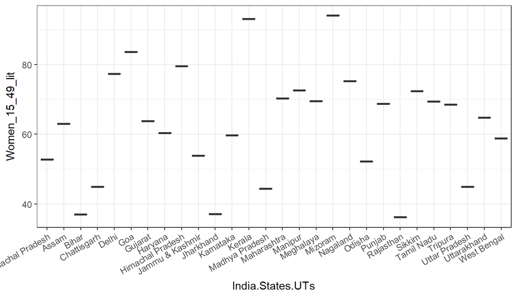

```r
ggplot(myData_tot_stat_n3, aes(x = India.States.UTs, y = Women_15_49_lit)) +
     geom_boxplot()+
  theme_bw() +
  theme(axis.text.x = element_text(angle = 30, hjust = 1))
```

```r
myData_tot_stat_n3 %>% summarise(mean_dd = mean(Women_15_49_lit), sd_dd = sd(Women_15_49_lit), n = n())
```

```
##    mean_dd    sd_dd  n
## 1 63.12857 15.75149 28
```

**EXPLAINATION**

STATISTICAL VALUES:- MEAN=63.128 STANDARD DEVIATION=15.751

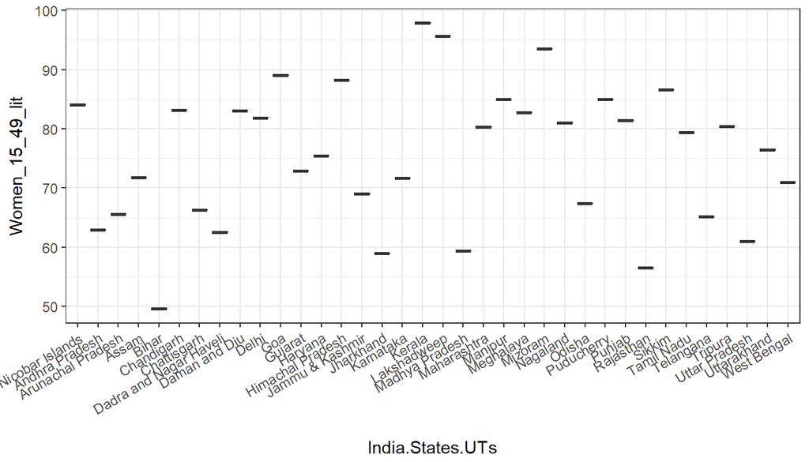

```r
ggplot(myData_tot_stat_n4, aes(x = India.States.UTs, y = Women_15_49_lit)) +
     geom_boxplot()+
  theme_bw() +
  theme(axis.text.x = element_text(angle = 30, hjust = 1))
```

```r
myData_tot_stat_n4 %>% summarise(mean_dd = mean(Women_15_49_lit), sd_dd = sd(Women_15_49_lit), n = n())
```

```
##    mean_dd    sd_dd  n
## 1 75.61389 11.76669 36
```

**EXPLAINATION**

STATISTICAL VALUES:- MEAN=75.61 STANDARD DEVIATION=11.766

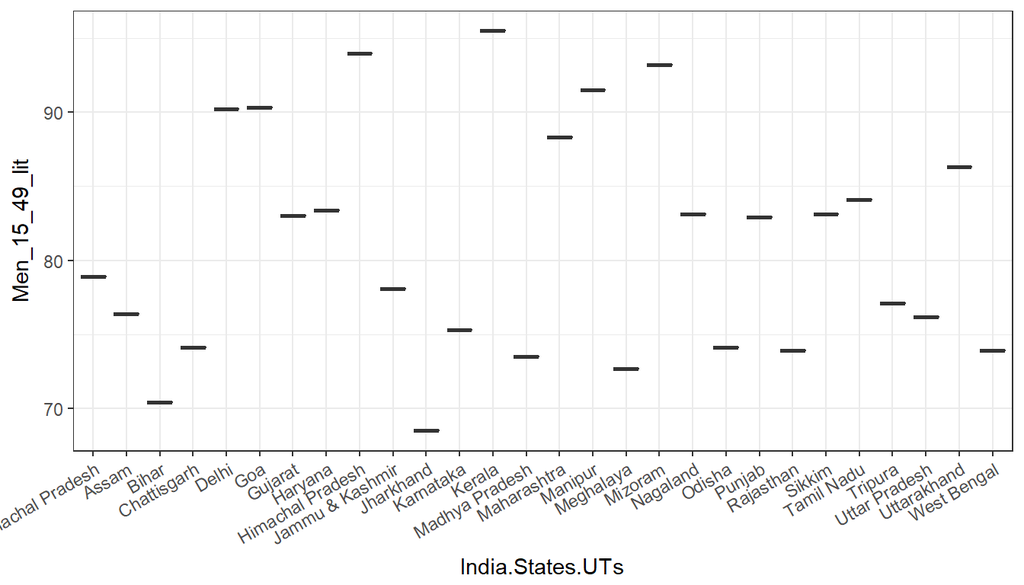

```r
ggplot(myData_tot_stat_n3, aes(x = India.States.UTs, y = Men_15_49_lit)) +
     geom_boxplot()+
  theme_bw() +
  theme(axis.text.x = element_text(angle = 30, hjust = 1))
```

```r
myData_tot_stat_n3 %>% summarise(mean_dd = mean(Men_15_49_lit), sd_dd = sd(Men_15_49_lit), n = n())
```

```
##    mean_dd    sd_dd  n
## 1 81.14286 7.737807 28
```

**EXPLAINATION**

STATISTICAL VALUES:- MEAN=81.142 STANDARD DEVIATION=7.737

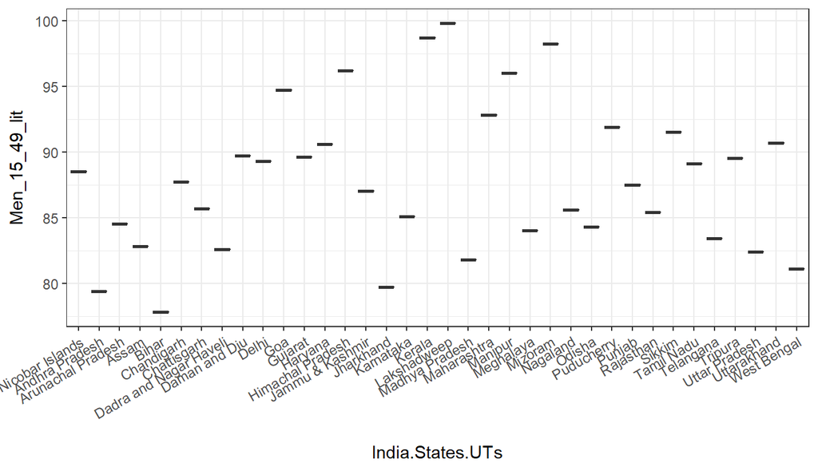

```r
ggplot(myData_tot_stat_n4, aes(x = India.States.UTs, y = Men_15_49_lit)) +
     geom_boxplot()+
  theme_bw() +
  theme(axis.text.x = element_text(angle = 30, hjust = 1))
```

```r
myData_tot_stat_n4 %>% summarise(mean_dd = mean(Men_15_49_lit), sd_dd = sd(Men_15_49_lit), n = n())
```

```
##    mean_dd    sd_dd  n
## 1 87.90556 5.657205 36
```

**EXPLAINATION**

The line graph shows that the men’s literacy rate is high in all the individual states in NFHS-4